# Assignment 4 for Statistical Computing and Empirical Methods: Data wrangling with R

Henry Reeve

# Introduction

This document describes your fourth assignment for Statistical Computing and Empirical Methods (Unit EMATM0061) on the MSc in Data Science. Before starting the assignment it is recommended that you first watch video lecture 4 entitled “Data wrangling with R”. The goal of this assignment is for you to gain an understanding of some of the basics of data wrangling with R using the dplyr library.

Begin by creating an Rmarkdown document with html output. You are not expected to hand in this piece of work, but it is a good idea to get used to using Rmarkdown.

You will need to load the Tidyverse library which is a superset of the dplyr library which we shall use for this assignment.

```r
library(tidyverse)
```

We shall also use the Hawks data set from the Stat2Data package, which we used in the previous assignment. The Hawks data set was created by Cornell College in Mount Vernon, Iowa and is available via the “Stat2Data” library:

```r
library(Stat2Data)
data("Hawks")
```

This will load a data frame called “Hawks” into your environment.

# 1 Select and filter functions

Use a combination of the **select()** and **filter()** functions to generate a data frame called “hSF” which is a sub-table of the original Hawks data frame with the following characteristics:

1. Your data frame should include the columns:
1. “Wing”,
2. “Weight”
3. “Tail”.
2. Your data frame should contain a row for every hawk such that:
1. They belong to the species of Red-Tailed hawks
2. They have weight at least 1kg.

Make use of the pipe operator to simplify your code.

How many variables does the dataframe hSF have? What would you say to communicate this information to a Machine Learning enthusiast?

How many examples does the dataframe hSF have? How many observations? How many examples?

# 2 The arrange function

Use the **arrange()** function to sort the hSF data frame created in the previous section so that the rows appear in order of increasing wing span.

Use the head command to print out the top five rows of your sorted data frame. Your results should look something like this:

```
##    Wing Weight Tail
## 1  37.2   1180  210
## 2 111.0   1340  226
## 3 199.0   1290  222
## 4 241.0   1320  235
## 5 262.0   1020  200
```

# 3 Join and rename functions

The species of Hawks within the data frame have been indicated via a two letter code. The correspondence between these codes and the full names is given by the following data frame.

```
##   species_code species_name_full
## 1           CH          Cooper's
## 2           RT        Red-tailed
## 3           SS     Sharp-shinned
```

Recreate the above data frame containing the correspondence between codes and the full species names and give your data frame an appropriate name.

Use a combination of the functions **left_join()**, the **rename()** and the **select()* functions to create a new data frame called “hawksFullName” which is the same as the “Hawks” data frame except that the Species column contains the full names rather than the two letter codes.

Use a combination of the **head()** and **select()** functions to print out the top seven rows of the columns “Species”, “Wing” and “Weight” of the data frame called “hawksFullName”. Do this without modifying the data frame you just created. Your result should something like this:

```
##         Species Wing Weight
## 1    Red-tailed  385    920
## 2    Red-tailed  376    930
## 3    Red-tailed  381    990
## 4      Cooper's  265    470
## 5 Sharp-shinned  205    170
## 6    Red-tailed  412   1090
## 7    Red-tailed  370    960
```

Does it matter what type of join function you use here? In what situations would it make a difference?

# 4 The mutate function

$$\text{Bird-BMI}:=1000\times\text{Weight}/\text{Wing-span}^2.$$

Use the **mutate()**, **select()** and **arange()** functions to create a new data frame called “hawksWithBMI” which has the same number of rows as the original Hawks data frame but only two columns - one with their Species and one with their “bird BMI”. The rows should appear in descending order of “bird BMI”. The top 8 rows of your data frame should look something like this:

```
##   Species  bird_BMI
## 1      RT 852.69973
## 2      RT 108.75741
## 3      RT  32.57493
## 4      RT  22.72688
## 5      CH  22.40818
## 6      RT  19.54932
## 7      CH  15.21998
## 8      RT  14.85927
```

Use the **filter()** function to remove those cases where the bird BMI exceeds 100 from your data frame. Then generate a violin plot of your data which shows the distribution of “bird BMIs” broken down by species. Your result should look something like this:

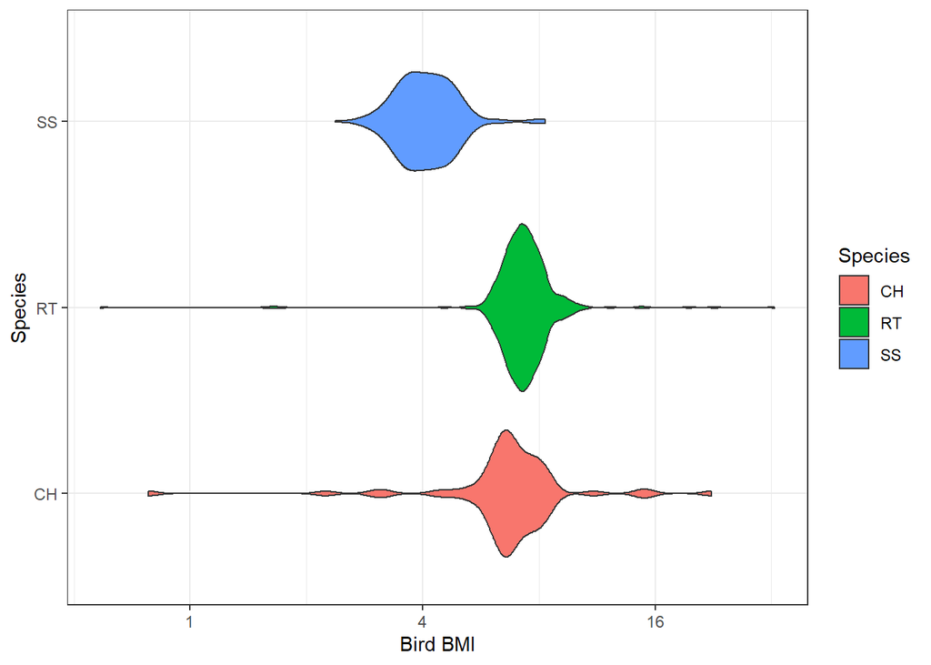

# 5 Summarize and group-by functions

Using the dataframe “hawksFullName”, from problem 3 above, in combination with the **summarize()** and the **groupby** functions, create a summary table, broken down by Hawk species, which contains the following summary quantities:

1. The number of rows;
2. The minimum wing span in centimeters;
3. The mean average wing span in centimeters;
4. The maximum wing span in centimeters;
5. The mean average of the ratio between wing span and tail length.

Your final result should look something like this:

```
## # A tibble: 3 x 6
##   Species       num_rows min_wing avg_wing max_wing avg_tail_wing_ratio
##   <chr>            <int>    <dbl>    <dbl>    <dbl>               <dbl>
## 1 Cooper's            70    145       244.      377                1.22
## 2 Red-tailed         577     37.2     383.      480                1.73
## 3 Sharp-shinned      261    143       185.      370                1.26
```

Next create a summary table of the following form: Your summary table will show the number of missing values, broken down by species, for the columns Wing, Weight, Culmen, Hallux, Tail, StandardTail, Tarsus and Crop. You can complete this task by combining the **select()**, **group_by()**, **summarize()**, **across()**, **everything()**, **sum()** and **is.na()** functions. You should end with a summary table of the following form:

```
## # A tibble: 3 x 9
##   Species        Wing Weight Culmen Hallux  Tail StandardTail Tarsus  Crop
##   <chr>         <int>  <int>  <int>  <int> <int>        <int>  <int> <int>
## 1 Cooper's          1      0      0      0     0           19     62    21
## 2 Red-tailed        0      5      4      3     0          250    538   254
## 3 Sharp-shinned     0      5      3      3     0           68    233    68
```

A fantastic source for learning more about dplyr is the Tidyverse website https://dplyr.tidyverse.org/index.html

[^1]: Both the “Healthy Hawks Society” and the concept of “bird BMI” were made up purely for this assignment.